# Introduction

> "Summarize for us the goal of this project and how machine learning is useful in trying to accomplish it. As part of your answer, give some background on the dataset and how it can be used to answer the project question."

> > [relevant rubric items: “data exploration”]

This project revolves around one of the most famous datasets of all time, then Enron corpus. Enron, an american energy company was at the center of one of the largest cases of fraud in history. Many executives at Enron were indicted for a variety of charges and some were later sentenced to prison.

The purpose of this project is to showcase the machine learning concepts and techniques learned throughout the Udacity course. To do this, I will attempt to build a classifier that can identify persons of interest (POIs) by training on data made public through the Enron email and financial datasets.

```python
# Import all libraries

import sys
import os
import pickle
import pandas as pd
import seaborn as sns
import matplotlib.pyplot as plt
import warnings

%pylab inline
# Change figure size into 8 by 6 inches
matplotlib.rcParams['figure.figsize'] = (8, 6)
warnings.filterwarnings('ignore')


from collections import defaultdict
from sklearn.metrics import accuracy_score, precision_score, recall_score, f1_score, confusion_matrix
from sklearn.feature_selection import SelectKBest
from sklearn.tree import DecisionTreeClassifier
from sklearn.model_selection import train_test_split, StratifiedShuffleSplit, GridSearchCV
from sklearn.naive_bayes import GaussianNB
from sklearn.ensemble import AdaBoostClassifier, RandomForestClassifier
from sklearn.preprocessing import MinMaxScaler
```

```python
# Change working directory
path = '/Users/Administrator/Desktop/Enron'

os.chdir(path)
```

# Exploratory Data Analysis

First, I will explore the data a bit to see what I'm working with. Below I find that there are 146 employees in the dataset, with 18 POIs and 128 non-POIs. The data also contains 21 features (14 are financial, 6 are email, and a POI label of True or False).

Furthermore, the dataset contains many missing values which forces me to make a decision of how to handle them. Later I will describe my method of cleansing the data.

```python
# Load in the dataset
with open('final_project_dataset.pkl', 'rb') as data_file:
    data_dict = pickle.load(data_file)
```

```python
# Total number of data points
print('There are {} employees in the dataset.'.format(len(data_dict)))
```

```
There are 146 employees in the dataset.
```

```python
# Allocation across classes (POI/non-POI)

poi_count = defaultdict(int)

for features_values in data_dict.values():
    poi_count[features_values['poi']] += 1

print('There are {} POIs and {} non-POIs.'.format(poi_count[True], poi_count[False]))
```

```
There are 18 POIs and 128 non-POIs.
```

```python
# Number of features
print('There are {} features.'.format(len(list(data_dict.values())[0])))

# Feature Names
list(list(data_dict.values())[0].keys())
```

```
There are 21 features.
```

```
['salary',
 'to_messages',
 'deferral_payments',
 'total_payments',
 'loan_advances',
 'bonus',
 'email_address',
 'restricted_stock_deferred',
 'deferred_income',
 'total_stock_value',
 'expenses',
 'from_poi_to_this_person',
 'exercised_stock_options',
 'from_messages',
 'other',
 'from_this_person_to_poi',
 'poi',
 'long_term_incentive',
 'shared_receipt_with_poi',
 'restricted_stock',
 'director_fees']
```

```python
# Analysis of features with missing values

nan_cts_poi = defaultdict(int)
nan_cts_non_poi = defaultdict(int)

for data_point in data_dict.values():
    if data_point['poi'] == True:
        for feature, value in data_point.items():
            if value == "NaN":
                nan_cts_poi[feature] += 1
    elif data_point['poi'] == False:
        for feature, value in data_point.items():
            if value == "NaN":
                nan_cts_non_poi[feature] += 1
    else:
        print('ERROR: Uncategorized Employee.')

nan_cts = pd.DataFrame([nan_cts_poi, nan_cts_non_poi]).T
nan_cts = nan_cts.fillna(value=0)
nan_cts.columns = ['# NaN in POIs', '# NaN in non-POIs']
nan_cts['# NaN total'] = nan_cts['# NaN in POIs'] + \
                               nan_cts['# NaN in non-POIs']
nan_cts['% NaN in POIs'] = nan_cts['# NaN in POIs'] / \
                                          poi_count[True] * 100
nan_cts['% NaN in non-POIs'] = nan_cts['# NaN in non-POIs'] / \
                                          poi_count[False] * 100
nan_cts['% NaN total'] = nan_cts['# NaN total'] / \
                                          len(data_dict) * 100

nan_cts
```

|  | # NaN in POIs | # NaN in non-POIs | # NaN total | % NaN in POIs | % NaN in non-POIs | % NaN total |
| --- | --- | --- | --- | --- | --- | --- |
| deferral_payments | 13.0 | 94.0 | 107.0 | 72.222222 | 73.43750 | 73.287671 |
| loan_advances | 17.0 | 125.0 | 142.0 | 94.444444 | 97.65625 | 97.260274 |
| restricted_stock_deferred | 18.0 | 110.0 | 128.0 | 100.000000 | 85.93750 | 87.671233 |
| director_fees | 18.0 | 111.0 | 129.0 | 100.000000 | 86.71875 | 88.356164 |
| exercised_stock_options | 6.0 | 38.0 | 44.0 | 33.333333 | 29.68750 | 30.136986 |
| long_term_incentive | 6.0 | 74.0 | 80.0 | 33.333333 | 57.81250 | 54.794521 |
| to_messages | 4.0 | 56.0 | 60.0 | 22.222222 | 43.75000 | 41.095890 |
| deferred_income | 7.0 | 90.0 | 97.0 | 38.888889 | 70.31250 | 66.438356 |
| from_poi_to_this_person | 4.0 | 56.0 | 60.0 | 22.222222 | 43.75000 | 41.095890 |
| from_messages | 4.0 | 56.0 | 60.0 | 22.222222 | 43.75000 | 41.095890 |
| from_this_person_to_poi | 4.0 | 56.0 | 60.0 | 22.222222 | 43.75000 | 41.095890 |
| shared_receipt_with_poi | 4.0 | 56.0 | 60.0 | 22.222222 | 43.75000 | 41.095890 |
| bonus | 2.0 | 62.0 | 64.0 | 11.111111 | 48.43750 | 43.835616 |
| salary | 1.0 | 50.0 | 51.0 | 5.555556 | 39.06250 | 34.931507 |
| restricted_stock | 1.0 | 35.0 | 36.0 | 5.555556 | 27.34375 | 24.657534 |
| email_address | 0.0 | 35.0 | 35.0 | 0.000000 | 27.34375 | 23.972603 |
| total_payments | 0.0 | 21.0 | 21.0 | 0.000000 | 16.40625 | 14.383562 |
| expenses | 0.0 | 51.0 | 51.0 | 0.000000 | 39.84375 | 34.931507 |
| other | 0.0 | 53.0 | 53.0 | 0.000000 | 41.40625 | 36.301370 |
| total_stock_value | 0.0 | 20.0 | 20.0 | 0.000000 | 15.62500 | 13.698630 |

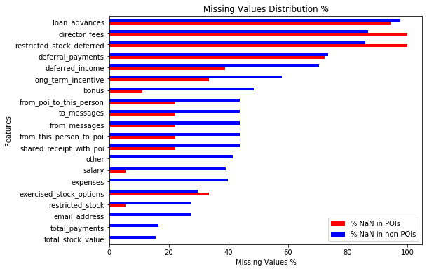

```python
# Plot distribution of missing values
ax = nan_cts.sort_values('# NaN total')[['% NaN in POIs', '% NaN in non-POIs']].plot(kind='barh',
                                                                                    stacked=False, color=['red','blue'])
ax.set_title('Missing Values Distribution %')
ax.set_xlabel('Missing Values %')
ax.set_ylabel('Features')
```

# Data Cleaning

As we see above, the number of NaN values is a little shocking. I turned to reading the documentaion "enron61702insiderpay.pdf" that provides the data schema and decided to split the NaN values into two categories (Financial & Email) that I will cleanse differently.

Financial data should be "0" instead of NaN, so I will replace those in the dataset.

Email data of 60 people is missing for:

- "from_messages"
- "from_poi_to_this_person"
- "from_this_person_to_poi"
- "shared_receipt_with_poi"
- "to_messages"

35 people don't have data for email_address, leaving 25 people with an email_address but no email data. I will assume that these 60 people are simply missing data on their email activity (rather than employees never using email) and give them the median of each email feature.

```python
# Create dataframe to replace NaN message corpus values with median values
data_df = pd.DataFrame(data_dict)
data_df = data_df.transpose()
```

```python
# Replace string 'NaN' values with NULL
data_df.replace(to_replace='NaN', value=numpy.nan, inplace=True)
```

```python
# Is any employee missing all data?
most_nans = data_df.count(axis=1)
most_nans.sort_values(ascending=True)
```

```
LOCKHART EUGENE E                 1
GRAMM WENDY L                     3
THE TRAVEL AGENCY IN THE PARK     3
WHALEY DAVID A                    3
WROBEL BRUCE                      3
                                 ..
DERRICK JR. JAMES V              18
FREVERT MARK A                   19
ALLEN PHILLIP K                  19
HAEDICKE MARK E                  19
LAY KENNETH L                    19
Length: 146, dtype: int64
```

```python
# Only employee missing all actionable data
data_df.loc['LOCKHART EUGENE E']
```

```
salary                         NaN
to_messages                    NaN
deferral_payments              NaN
total_payments                 NaN
loan_advances                  NaN
bonus                          NaN
email_address                  NaN
restricted_stock_deferred      NaN
deferred_income                NaN
total_stock_value              NaN
expenses                       NaN
from_poi_to_this_person        NaN
exercised_stock_options        NaN
from_messages                  NaN
other                          NaN
from_this_person_to_poi        NaN
poi                          False
long_term_incentive            NaN
shared_receipt_with_poi        NaN
restricted_stock               NaN
director_fees                  NaN
Name: LOCKHART EUGENE E, dtype: object
```

```python
# Replace NaN values for email datapoints with median value of feature
data_df.from_messages.fillna(data_df.from_messages.median(), inplace=True)
data_df.from_poi_to_this_person.fillna(data_df.from_poi_to_this_person.median(), inplace=True)
data_df.from_this_person_to_poi.fillna(data_df.from_this_person_to_poi.median(), inplace=True)
data_df.to_messages.fillna(data_df.to_messages.median(), inplace=True)
data_df.shared_receipt_with_poi.fillna(data_df.shared_receipt_with_poi.median(), inplace=True)
```

```python
# Replace remaining financial NULLs with 0
data_df.replace(to_replace=numpy.nan, value=0, inplace=True)
```

```python
# Convert back to dict
data_dict = data_df.to_dict(orient = 'index')
```

```python
# Create function for easy conversion into Pandas DataFrame with proper format
def allFeaturesFormat(data_dict):

    temp_list = []

    for name, features_values in data_dict.items():
        temp_dict = {}
        temp_dict['name'] = name
        for feature, value in features_values.items():
            if feature in ['poi', 'email_address']:
                temp_dict[feature] = value
            else:
                temp_dict[feature] = float(value)
        temp_list.append(temp_dict)
    df = pd.DataFrame(temp_list)

    return df
```

# Outliers

> "Were there any outliers in the data when you got it, and how did you handle those?"

> > [relevant rubric items: “Outlier Investigation”]

Now that the data is clean, I can begin identifying and removing certain outliers. First, I remove "LOCKHART EUGENE E" who I earlier found to have all null values. My next thought is to plot the bonus vs salary as I did in the course to see if there were any obvious outliers. I found that there was an entry called "TOTAL" which certainly should not be included. This led me to inspect the employee names manually to see if there were any others that were not names of employees. I found another named "THE TRAVEL AGENCY IN THE PARK" and removed it as well.

Then, I looked at the bonus vs salary plot again and noticed some values far removed from the cluster. I inspect the outliers for bonus and salary and find that they are indeed just grossly overpaid employees who should be kept in the dataset.

```python
# Remove employee with no data
data_dict.pop('LOCKHART EUGENE E', 0)
```

```
{'salary': 0.0,
 'to_messages': 1211.0,
 'deferral_payments': 0.0,
 'total_payments': 0.0,
 'loan_advances': 0.0,
 'bonus': 0.0,
 'email_address': 0,
 'restricted_stock_deferred': 0.0,
 'deferred_income': 0.0,
 'total_stock_value': 0.0,
 'expenses': 0.0,
 'from_poi_to_this_person': 35.0,
 'exercised_stock_options': 0.0,
 'from_messages': 41.0,
 'other': 0.0,
 'from_this_person_to_poi': 8.0,
 'poi': False,
 'long_term_incentive': 0.0,
 'shared_receipt_with_poi': 740.5,
 'restricted_stock': 0.0,
 'director_fees': 0.0}
```

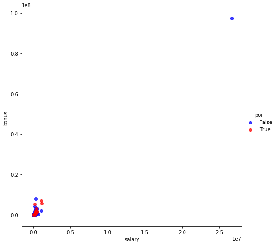

```python
# Plot bonus vs salary to see outliers
df_1 = allFeaturesFormat(data_dict)
g = sns.FacetGrid(df_1, hue='poi', palette=['blue','red'], height=7)
g.map(plt.scatter, 'salary', 'bonus', alpha=.75)
g.add_legend()
```

```python
# Remove the obvious outliers
data_dict.pop('TOTAL', 0)
data_dict.pop("THE TRAVEL AGENCY IN THE PARK", 0)
```

```
{'salary': 0.0,
 'to_messages': 1211.0,
 'deferral_payments': 0.0,
 'total_payments': 362096.0,
 'loan_advances': 0.0,
 'bonus': 0.0,
 'email_address': 0,
 'restricted_stock_deferred': 0.0,
 'deferred_income': 0.0,
 'total_stock_value': 0.0,
 'expenses': 0.0,
 'from_poi_to_this_person': 35.0,
 'exercised_stock_options': 0.0,
 'from_messages': 41.0,
 'other': 362096.0,
 'from_this_person_to_poi': 8.0,
 'poi': False,
 'long_term_incentive': 0.0,
 'shared_receipt_with_poi': 740.5,
 'restricted_stock': 0.0,
 'director_fees': 0.0}
```

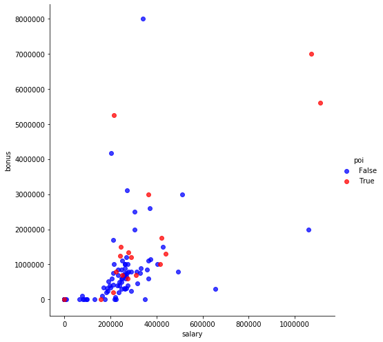

```python
# Plot bonus vs salary to see outliers
df_2 = allFeaturesFormat(data_dict)
g = sns.FacetGrid(df_2, hue='poi', palette=['blue','red'], height=7)
g.map(plt.scatter, 'salary', 'bonus', alpha=.75)
g.add_legend()
```

```python
# Identify outliers who have salaries greater than 600k or bonuses greater than 4m

# Salary outliers
print('*'*20)
print('Salary outliers:')
print('*'*20)
for name, value in data_dict.items():
    if data_dict[name]["salary"] >= 600000:
        print("Name: ", name)
        print("Salary: ", value['salary'])

print('*'*20)
print('Bonus outliers:')
print('*'*20)

# Bonus outliers
for name, value in data_dict.items():
    if data_dict[name]["bonus"] >= 4000000:
        print("Name: ", name)
        print("Bonus: ", value['bonus'])

print('*'*20)
print('Salary & Bonus outliers:')
print('*'*20)

# Salary & Bonus combination outliers
for name, value in data_dict.items():
    if data_dict[name]["bonus"] >= 4000000 and data_dict[name]["salary"] >= 600000:
        print("Name: ", name)
        print("Salary: ", value['salary'])
        print("Bonus: ", value['bonus'])
```

```
Salary outliers:
Name:  LAY KENNETH L
Salary:  1072321.0
Name:  SKILLING JEFFREY K
Salary:  1111258.0
Name:  PICKERING MARK R
Salary:  655037.0
Name:  FREVERT MARK A
Salary:  1060932.0
Bonus outliers:
Name:  LAVORATO JOHN J
Bonus:  8000000.0
Name:  LAY KENNETH L
Bonus:  7000000.0
Name:  BELDEN TIMOTHY N
Bonus:  5249999.0
Name:  SKILLING JEFFREY K
Bonus:  5600000.0
Name:  ALLEN PHILLIP K
Bonus:  4175000.0
Salary & Bonus outliers:
Name:  LAY KENNETH L
Salary:  1072321.0
Bonus:  7000000.0
Name:  SKILLING JEFFREY K
Salary:  1111258.0
Bonus:  5600000.0
```

# Engineering Features

> "As part of the assignment, you should attempt to engineer your own feature that does not come ready-made in the dataset -- explain what feature you tried to make, and the rationale behind it. (You do not necessarily have to use it in the final analysis, only engineer and test it.)"

> > [relevant rubric item: “create new features”]

I decided to engineer three new features:

- fraction_from_poi: ratio of the messages from POI to this person against all the messages sent to this person.
- fraction_to_poi: ratio from this person to POI against all messages from this person
- total_compensation: the sum of total_payments and total_stock_value

I landed on these features because co-conspirators in fraud tend to make a ton of money and talk to each other more often than people outside of their circle.

```python
# Calculate fraction of messages to/from POIs
def computeFraction(poi_messages, all_messages):

    fraction = 0

    if poi_messages != 0 and all_messages != 0:
        fraction = poi_messages / all_messages

    return fraction
```

```python
# Calculate total compensation
def computeTotal(total_payments, total_stock_value):

    total = total_payments + total_stock_value

    return total
```

```python
# Create new features
for data_point in data_dict.values():

    # Create feature fraction_from_poi
    from_poi_to_this_person = data_point['from_poi_to_this_person']
    to_messages = data_point['to_messages']
    fraction_from_poi = computeFraction(from_poi_to_this_person, to_messages)
    data_point['fraction_from_poi'] = fraction_from_poi

    # Create feature fraction_to_poi
    from_this_person_to_poi = data_point['from_this_person_to_poi']
    from_messages = data_point['from_messages']
    fraction_to_poi = computeFraction(from_this_person_to_poi, from_messages)
    data_point['fraction_to_poi'] = fraction_to_poi

    # Create feature total_compensation
    total_payments = data_point['total_payments']
    total_stock_value = data_point['total_stock_value']
    data_point['total_compensation'] = computeTotal(total_payments, total_stock_value)
```

# Feature scaling....

> "Did you have to do any scaling? Why or why not?"

> > [relevant rubric item: “properly scale features”]

Since the scale of our features vary wildly from one-another, I performed some feature scaling. Depending on what algorithm I pick later, it could impact the analysis. However, since I decided to use Decision Tree for feature selection and AdaBoost for a classifier, the performance is not affected by the scaling as they are not based on Euclidean distances. It is still a good practice.

```python
# Prepare features and labels for machine learning
work_df = allFeaturesFormat(data_dict)

# Subset dataframe with only numeric columns as features
features = work_df.drop(['poi', 'name', 'email_address'], axis=1)
```

```python
# Features before scaling
features
```

|  | salary | to_messages | deferral_payments | total_payments | loan_advances | bonus | restricted_stock_deferred | deferred_income | total_stock_value | expenses | ... | from_messages | other | from_this_person_to_poi | long_term_incentive | shared_receipt_with_poi | restricted_stock | director_fees | fraction_from_poi | fraction_to_poi | total_compensation |
| --- | --- | --- | --- | --- | --- | --- | --- | --- | --- | --- | --- | --- | --- | --- | --- | --- | --- | --- | --- | --- | --- |
| 0 | 365788.0 | 807.0 | 0.0 | 1061827.0 | 0.0 | 600000.0 | 0.0 | 0.0 | 585062.0 | 94299.0 | ... | 29.0 | 1740.0 | 1.0 | 0.0 | 702.0 | 585062.0 | 0.0 | 0.047088 | 0.034483 | 1646889.0 |
| 1 | 267102.0 | 1211.0 | 1295738.0 | 5634343.0 | 0.0 | 1200000.0 | 0.0 | -1386055.0 | 10623258.0 | 11200.0 | ... | 41.0 | 2660303.0 | 8.0 | 1586055.0 | 740.5 | 3942714.0 | 0.0 | 0.028902 | 0.195122 | 16257601.0 |
| 2 | 170941.0 | 1211.0 | 0.0 | 211725.0 | 0.0 | 350000.0 | 0.0 | -400729.0 | 6678735.0 | 78552.0 | ... | 41.0 | 12961.0 | 8.0 | 0.0 | 740.5 | 1788391.0 | 0.0 | 0.028902 | 0.195122 | 6890460.0 |
| 3 | 0.0 | 764.0 | 0.0 | 0.0 | 0.0 | 0.0 | 0.0 | 0.0 | 1038185.0 | 0.0 | ... | 12.0 | 0.0 | 0.0 | 0.0 | 58.0 | 386335.0 | 0.0 | 0.013089 | 0.000000 | 1038185.0 |
| 4 | 243293.0 | 1045.0 | 0.0 | 288682.0 | 0.0 | 1500000.0 | 0.0 | -3117011.0 | 6391065.0 | 34039.0 | ... | 32.0 | 11350.0 | 21.0 | 1617011.0 | 1035.0 | 853064.0 | 0.0 | 0.030622 | 0.656250 | 6679747.0 |
| ... | ... | ... | ... | ... | ... | ... | ... | ... | ... | ... | ... | ... | ... | ... | ... | ... | ... | ... | ... | ... | ... |
| 138 | 0.0 | 1211.0 | 0.0 | 119292.0 | 0.0 | 0.0 | 0.0 | 0.0 | 0.0 | 0.0 | ... | 41.0 | 0.0 | 8.0 | 0.0 | 740.5 | 0.0 | 119292.0 | 0.028902 | 0.195122 | 119292.0 |
| 139 | 415189.0 | 1892.0 | 0.0 | 1868758.0 | 0.0 | 1000000.0 | 0.0 | -235000.0 | 2502063.0 | 30674.0 | ... | 49.0 | 307895.0 | 12.0 | 350000.0 | 1585.0 | 2502063.0 | 0.0 | 0.030655 | 0.244898 | 4370821.0 |
| 140 | 265214.0 | 533.0 | 227449.0 | 1092663.0 | 0.0 | 600000.0 | 0.0 | 0.0 | 3745048.0 | 0.0 | ... | 29.0 | 0.0 | 0.0 | 0.0 | 300.0 | 563798.0 | 0.0 | 0.000000 | 0.000000 | 4837711.0 |
| 141 | 278601.0 | 865.0 | 0.0 | 875760.0 | 0.0 | 800000.0 | 0.0 | -300000.0 | 1080988.0 | 96268.0 | ... | 22.0 | 891.0 | 11.0 | 0.0 | 772.0 | 315068.0 | 0.0 | 0.217341 | 0.500000 | 1956748.0 |
| 142 | 274975.0 | 873.0 | 0.0 | 1272284.0 | 0.0 | 600000.0 | 0.0 | 0.0 | 778546.0 | 125978.0 | ... | 16.0 | 200308.0 | 6.0 | 71023.0 | 874.0 | 393818.0 | 0.0 | 0.059565 | 0.375000 | 2050830.0 |

143 rows × 22 columns

```python
# Scale features
scaler = MinMaxScaler(copy=False)
scaler.fit(features)
scaler.transform(features)

# Labels are the 'POI' column
labels = work_df.poi
```

```python
# Features after scaling
features
```

|  | salary | to_messages | deferral_payments | total_payments | loan_advances | bonus | restricted_stock_deferred | deferred_income | total_stock_value | expenses | ... | from_messages | other | from_this_person_to_poi | long_term_incentive | shared_receipt_with_poi | restricted_stock | director_fees | fraction_from_poi | fraction_to_poi | total_compensation |
| --- | --- | --- | --- | --- | --- | --- | --- | --- | --- | --- | --- | --- | --- | --- | --- | --- | --- | --- | --- | --- | --- |
| 0 | 0.329166 | 0.049695 | 0.015698 | 0.010253 | 0.0 | 0.07500 | 0.103654 | 1.000000 | 0.012800 | 0.412213 | ... | 0.001184 | 0.000168 | 0.001642 | 0.000000 | 0.126835 | 0.183665 | 0.000000 | 0.216655 | 0.034483 | 0.010787 |
| 1 | 0.240360 | 0.076464 | 0.214142 | 0.054407 | 0.0 | 0.15000 | 0.103654 | 0.604480 | 0.217018 | 0.048959 | ... | 0.002020 | 0.256793 | 0.013136 | 0.308245 | 0.133810 | 0.377009 | 0.000000 | 0.132979 | 0.195122 | 0.106489 |
| 2 | 0.153827 | 0.076464 | 0.015698 | 0.002044 | 0.0 | 0.04375 | 0.103654 | 0.885649 | 0.136770 | 0.343377 | ... | 0.002020 | 0.001251 | 0.013136 | 0.000000 | 0.133810 | 0.252956 | 0.000000 | 0.132979 | 0.195122 | 0.045133 |
| 3 | 0.000000 | 0.046846 | 0.015698 | 0.000000 | 0.0 | 0.00000 | 0.103654 | 1.000000 | 0.022018 | 0.000000 | ... | 0.000000 | 0.000000 | 0.000000 | 0.000000 | 0.010147 | 0.172221 | 0.000000 | 0.060223 | 0.000000 | 0.006800 |
| 4 | 0.218935 | 0.065465 | 0.015698 | 0.002788 | 0.0 | 0.18750 | 0.103654 | 0.110540 | 0.130918 | 0.148796 | ... | 0.001393 | 0.001096 | 0.034483 | 0.314261 | 0.187172 | 0.199097 | 0.000000 | 0.140894 | 0.656250 | 0.043753 |
| ... | ... | ... | ... | ... | ... | ... | ... | ... | ... | ... | ... | ... | ... | ... | ... | ... | ... | ... | ... | ... | ... |
| 138 | 0.000000 | 0.076464 | 0.015698 | 0.001152 | 0.0 | 0.00000 | 0.103654 | 1.000000 | 0.000897 | 0.000000 | ... | 0.002020 | 0.000000 | 0.013136 | 0.000000 | 0.133810 | 0.149975 | 0.865288 | 0.132979 | 0.195122 | 0.000781 |
| 139 | 0.373621 | 0.121588 | 0.015698 | 0.018045 | 0.0 | 0.12500 | 0.103654 | 0.932941 | 0.051799 | 0.134086 | ... | 0.002577 | 0.029720 | 0.019704 | 0.068021 | 0.286827 | 0.294052 | 0.000000 | 0.141047 | 0.244898 | 0.028629 |
| 140 | 0.238661 | 0.031540 | 0.050532 | 0.010551 | 0.0 | 0.07500 | 0.103654 | 1.000000 | 0.077087 | 0.000000 | ... | 0.001184 | 0.000000 | 0.000000 | 0.000000 | 0.053995 | 0.182440 | 0.000000 | 0.000000 | 0.000000 | 0.031687 |
| 141 | 0.250708 | 0.053538 | 0.015698 | 0.008457 | 0.0 | 0.10000 | 0.103654 | 0.914393 | 0.022889 | 0.420820 | ... | 0.000697 | 0.000086 | 0.018062 | 0.000000 | 0.139518 | 0.168117 | 0.000000 | 1.000000 | 0.500000 | 0.012817 |
| 142 | 0.247445 | 0.054068 | 0.015698 | 0.012286 | 0.0 | 0.07500 | 0.103654 | 1.000000 | 0.016736 | 0.550692 | ... | 0.000279 | 0.019335 | 0.009852 | 0.013803 | 0.158000 | 0.172652 | 0.000000 | 0.274061 | 0.375000 | 0.013433 |

143 rows × 22 columns

# Feature Selection

> "What features did you end up using in your POI identifier, and what selection process did you use to pick them? In your feature selection step, if you used an algorithm like a decision tree, please also give the feature importances of the features that you use, and if you used an automated feature selection function like SelectKBest, please report the feature scores and reasons for your choice of parameter values."

> > [relevant rubric item: “intelligently select features”]

I turned to SelectKBest and DecisionTree as a way to select the best features. Both algorithms produce a score for the importance of each feature.

Those scores are listed below:

```python
# Split the whole dataset into stratified training/validation and test sets
# Training/validation set is used for building the model
# Test set is reserved for final model assessment
sss = StratifiedShuffleSplit(n_splits=1000, test_size=0.3, random_state=69)
```

```python
# Calculates average feature scores for each feature
def feature_scores(features, labels, cv, selector, score_attr):

    feature_names = features.columns.values
    feature_scores = defaultdict(list)

    for train_indices, test_indices in cv.split(features, labels):

        features_train = features.values[train_indices]
        features_test = features.values[test_indices]
        labels_train = labels.values[train_indices]
        labels_test = labels.values[test_indices]

        slct = selector
        slct.fit(features_train, labels_train)

        for feature_name, feature_score in zip(feature_names, getattr(slct, score_attr)):
            feature_scores[feature_name].append(feature_score)

    feature_scores = pd.DataFrame(feature_scores)
    feature_scores_avg = feature_scores.mean()
    feature_scores_avg = feature_scores_avg.sort_values(ascending=False)

    return feature_scores_avg
```

```python
# Feature selection using SelectKBest method
selector = SelectKBest(k='all')
feature_scores_avg = feature_scores(features, labels, sss, selector, 'scores_')
display(feature_scores_avg)
features_selectKBest_all = list(feature_scores_avg.index)
```

```
exercised_stock_options      18.106307
total_stock_value            17.735246
bonus                        16.490873
salary                       13.513565
total_compensation           13.155457
fraction_to_poi              10.003509
deferred_income               9.165521
long_term_incentive           8.606908
restricted_stock              7.541260
total_payments                6.491674
shared_receipt_with_poi       5.790194
loan_advances                 5.304641
expenses                      4.627460
from_poi_to_this_person       3.777962
other                         3.649931
from_this_person_to_poi       2.175068
director_fees                 1.530289
fraction_from_poi             1.487623
to_messages                   1.065104
deferral_payments             0.314097
restricted_stock_deferred     0.274289
from_messages                 0.245452
dtype: float64
```

```python
# Feature selection using DecisionTree method
selector = DecisionTreeClassifier()
feature_scores_avg = feature_scores(features, labels, sss, selector, 'feature_importances_')
display(feature_scores_avg)
features_DecicionTree_all = list(feature_scores_avg.index)
```

```
fraction_to_poi              0.149635
bonus                        0.121929
exercised_stock_options      0.111874
other                        0.107205
expenses                     0.088519
shared_receipt_with_poi      0.062411
total_stock_value            0.053412
deferred_income              0.043006
total_payments               0.038404
restricted_stock             0.033414
long_term_incentive          0.030144
from_this_person_to_poi      0.026133
total_compensation           0.026049
from_poi_to_this_person      0.024351
from_messages                0.021529
salary                       0.020756
fraction_from_poi            0.018862
to_messages                  0.013515
deferral_payments            0.006721
loan_advances                0.001157
restricted_stock_deferred    0.000871
director_fees                0.000103
dtype: float64
```

# Pick an Algorithm

> "What algorithm did you end up using? What other one(s) did you try? How did model performance differ between algorithms?"

> > [relevant rubric item: “pick an algorithm”]

I combined three algorithms with each of my previous feature selection methods, for a total of 6 combinations. I then selected the best of the bunch based on their f1 score.

The classifiers used were Naive Bayes, AdaBoost, and Random Forest.

For each combination, I recorded the following evaluation metrics for a varying number of features:

- accuracy
- precision
- recall
- f1 score

In the end, an AdaBoost classifier with 5 DecisionTree features were selected with an f1 score of over 0.45!

```python
# Calculate accuracy, precision, recall, f1 score and f2 score for a given model
def metrics_scores(features_n, labels, cv, clf):

    true_negatives = 0
    false_negatives = 0
    true_positives = 0
    false_positives = 0

    for train_indices, test_indices in cv.split(features_n, labels):

        features_train = features_n.values[train_indices]
        features_test = features_n.values[test_indices]
        labels_train = labels.values[train_indices]
        labels_test = labels.values[test_indices]

        clf.fit(features_train, labels_train)
        labels_pred = clf.predict(features_test)

        for prediction, truth in zip(labels_pred, labels_test):
            if prediction == 0 and truth == 0:
                true_negatives += 1
            elif prediction == 0 and truth == 1:
                false_negatives += 1
            elif prediction == 1 and truth == 0:
                false_positives += 1
            elif prediction == 1 and truth == 1:
                true_positives += 1

    total_predictions = true_negatives+false_negatives+false_positives+true_positives
    accuracy = (true_positives+true_negatives)/total_predictions
    precision = true_positives/(true_positives+false_positives)
    recall = true_positives/(true_positives+false_negatives)
    f1 = 2*true_positives/(2*true_positives+false_positives+false_negatives)
    f2 = (1+2*2)*precision*recall/(4*precision+recall)

    return (accuracy, precision, recall, f1, f2)
```

```python
# Calculate and plot evaluation metrics vs number of features for a given model
def feature_num_scores(features, labels, feature_names_by_score, cv, clf):

    num_features_accuracy_scores = []
    num_features_percision_scores = []
    num_features_recall_scores = []
    num_features_f1_scores = []

    for n in range(len(feature_names_by_score)):

        # Subset n features with the n highest feature scores
        features_n = features[feature_names_by_score[:n+1]]

        accuracy, precision, recall, f1, _ = metrics_scores(features_n, labels, cv, clf)

        num_features_accuracy_scores.append(accuracy)
        num_features_percision_scores.append(precision)
        num_features_recall_scores.append(recall)
        num_features_f1_scores.append(f1)

    scores_df = pd.DataFrame({
            'Number of features': range(1, len(num_features_accuracy_scores)+1),
            'Accuracy': num_features_accuracy_scores,
            'Precision': num_features_percision_scores,
            'Recall': num_features_recall_scores,
            'f1': num_features_f1_scores
        })

    scores_df.plot(x='Number of features', xticks=range(1, len(num_features_accuracy_scores)+1),colormap='hsv')

    return scores_df
```

```python
# Due to running time, 250 shuffles are used instead of 1000 shuffles for algorithm selection
sss_250 = StratifiedShuffleSplit(n_splits=250, test_size=0.3, random_state=69)
```

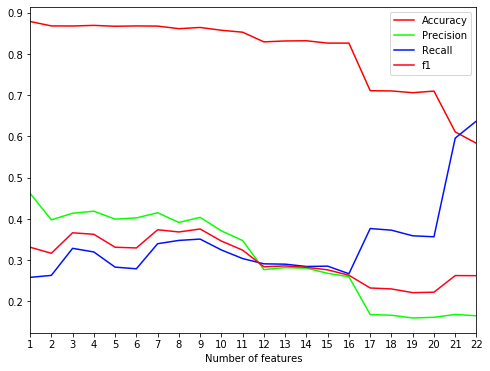

```python
# Naive Bayes with SelectKBest features
nb_kbest_clf = GaussianNB()
scores_NaiveBayes_SelectKBest_df = feature_num_scores(features, labels, features_selectKBest_all, sss_250, nb_kbest_clf)
```

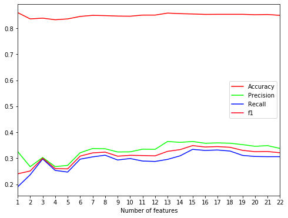

```python
# AdaBoost with SelectKBest features
ada_kbest_clf = AdaBoostClassifier()
scores_AdaBoost_SelectKBest_df = feature_num_scores(features, labels, features_selectKBest_all, sss_250, ada_kbest_clf)
```

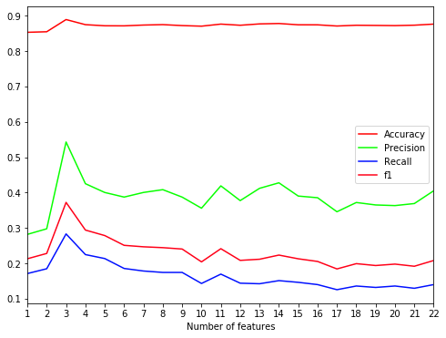

```python
# Random Forest with SelectKBest features
rf_kbest_clf = RandomForestClassifier()
scores_RandomForest_SelectKBest_df = feature_num_scores(features, labels, features_selectKBest_all, sss_250, rf_kbest_clf)
```

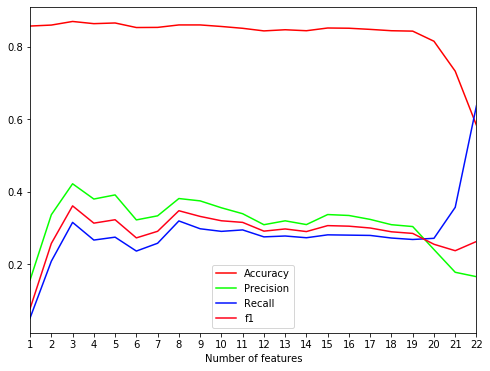

```python
# Naive Bayes with DecisionTree features
nb_dt_clf = GaussianNB()
scores_NaiveBayes_DecisionTree_df = feature_num_scores(features, labels, features_DecicionTree_all, sss_250, nb_dt_clf)
```

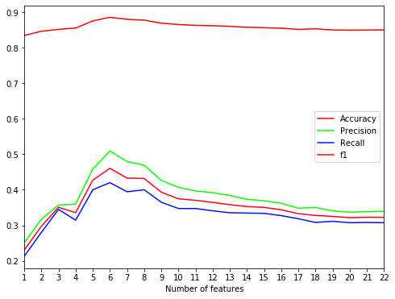

```python
# AdaBoost with DecisionTree features
ada_dt_clf = AdaBoostClassifier()
scores_AdaBoost_DecisionTree_df = feature_num_scores(features, labels, features_DecicionTree_all, sss_250, ada_dt_clf)
```

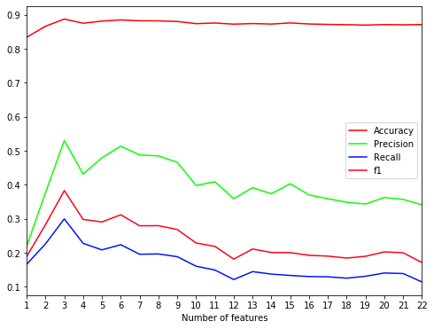

```python
# Random Forest with DecisionTree features
rf_dt_clf = RandomForestClassifier()
scores_RandomForest_DecisionTree_df = feature_num_scores(features, labels, features_DecicionTree_all, sss_250, rf_dt_clf)
```

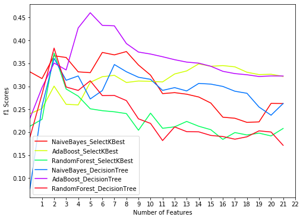

```python
# Plot f1 scores of all previous 6 combinations of classifier methods and feature selection methods
f1_df = pd.DataFrame([scores_NaiveBayes_SelectKBest_df['f1'],
                     scores_AdaBoost_SelectKBest_df['f1'],
                     scores_RandomForest_SelectKBest_df['f1'],
                     scores_NaiveBayes_DecisionTree_df['f1'],
                     scores_AdaBoost_DecisionTree_df['f1'],
                     scores_RandomForest_DecisionTree_df['f1']]).T
f1_df.columns = ['NaiveBayes_SelectKBest',
                'AdaBoost_SelectKBest',
                'RandomForest_SelectKBest',
                'NaiveBayes_DecisionTree',
                'AdaBoost_DecisionTree',
                'RandomForest_DecisionTree']
ax = f1_df.plot(xticks=arange(1, f1_df.shape[0]+1), colormap='hsv')
ax.set_xlabel('Number of Features')
ax.set_ylabel('f1 Scores')
```

```python
# Create list of used features
features_DecisionTree_5 = features_DecicionTree_all[:5]
display("Features selected for AdaBoost model:", features_DecisionTree_5)
```

```
'Features selected for AdaBoost model:'
```

```
['fraction_to_poi', 'bonus', 'exercised_stock_options', 'other', 'expenses']
```

# Tuning

> "What does it mean to tune the parameters of an algorithm, and what can happen if you don’t do this well? How did you tune the parameters of your particular algorithm? What parameters did you tune? (Some algorithms do not have parameters that you need to tune -- if this is the case for the one you picked, identify and briefly explain how you would have done it for the model that was not your final choice or a different model that does utilize parameter tuning, e.g. a decision tree classifier)."

> > [relevant rubric items: “discuss parameter tuning”, “tune the algorithm”]

Parameter tuning is the process of adjusting parameters for a given algorithm to produce an optimal performance of a model regarding a specific problem.

It can be dangerous if not done well, such as overfitting, because the model will perform poorly in a real world scenario.

To tune my parameters I decided to use GridSearchCV to do the painstaking work for me.

```python
param_grid = dict(base_estimator__max_depth = [None, 1, 3, 5],
                  base_estimator__class_weight = [None, 'balanced'],
                  n_estimators = [25, 50, 100])
gs = GridSearchCV(estimator=AdaBoostClassifier(base_estimator=DecisionTreeClassifier(random_state=69),
                                                random_state=69),
                   param_grid=param_grid,
                   scoring='f1',
                   cv=sss_250)
gs.fit(features[features_DecisionTree_5], labels)
clf = gs.best_estimator_
```

```python
# Grid scores
means = gs.cv_results_['mean_test_score']
stds = gs.cv_results_['std_test_score']
scores_df = pd.DataFrame([means, stds]).T
scores_df.columns = ['mean_test_score', 'std_test_score']
params_df = pd.DataFrame(gs.cv_results_['params'])
grid_scores_df = pd.concat([scores_df, params_df], axis=1)
grid_scores_df.sort_values('mean_test_score', ascending=False)
```

|  | mean_test_score | std_test_score | base_estimator__class_weight | base_estimator__max_depth | n_estimators |
| --- | --- | --- | --- | --- | --- |
| 8 | 0.456538 | 0.200755 | None | 3.0 | 100 |
| 20 | 0.454183 | 0.196836 | balanced | 3.0 | 100 |
| 7 | 0.451797 | 0.203329 | None | 3.0 | 50 |
| 19 | 0.448554 | 0.189616 | balanced | 3.0 | 50 |
| 6 | 0.440781 | 0.205734 | None | 3.0 | 25 |
| 22 | 0.438528 | 0.207592 | balanced | 5.0 | 50 |
| 12 | 0.437930 | 0.190181 | balanced | NaN | 25 |
| 13 | 0.437930 | 0.190181 | balanced | NaN | 50 |
| 14 | 0.437930 | 0.190181 | balanced | NaN | 100 |
| 10 | 0.433192 | 0.195229 | None | 5.0 | 50 |
| 9 | 0.432101 | 0.200191 | None | 5.0 | 25 |
| 23 | 0.431301 | 0.205064 | balanced | 5.0 | 100 |
| 18 | 0.429790 | 0.199814 | balanced | 3.0 | 25 |
| 15 | 0.429111 | 0.188299 | balanced | 1.0 | 25 |
| 11 | 0.426242 | 0.200078 | None | 5.0 | 100 |
| 21 | 0.422153 | 0.203406 | balanced | 5.0 | 25 |
| 16 | 0.419254 | 0.202765 | balanced | 1.0 | 50 |
| 17 | 0.416742 | 0.210888 | balanced | 1.0 | 100 |
| 5 | 0.414885 | 0.213587 | None | 1.0 | 100 |
| 4 | 0.410175 | 0.205389 | None | 1.0 | 50 |
| 3 | 0.398464 | 0.203382 | None | 1.0 | 25 |
| 1 | 0.383216 | 0.170312 | None | NaN | 50 |
| 2 | 0.383216 | 0.170312 | None | NaN | 100 |
| 0 | 0.383216 | 0.170312 | None | NaN | 25 |

# Validation and Evaluation

> "What is validation, and what’s a classic mistake you can make if you do it wrong? How did you validate your analysis? Give at least 2 evaluation metrics and your average performance for each of them. Explain an interpretation of your metrics that says something human-understandable about your algorithm’s performance."

> > [relevant rubric items: “discuss validation”, “validation strategy”, “usage of evaluation metrics”]

Validation involves gauging a model's performance using a dataset that is independent of the training dataset. This can be a great way to predict how well the model will generalize for unexpected data.

Because of the small number of datapoints and even fewer POIs, I decided to use StratifiedShuffleSplit to randomly split the entire dataset, and use the entire dataset both for constructing and evaluating the model. This will generate more stable evaluation metrics from an imbalanced dataset, but the drawback is that the metrics will be optimistic and may perform poorly down the road.

The metrics I used to evaluate the algorithm's were accuracy, precision, recall, and f1 score. The most important are recall, precision, and f1 (a combination of the two). Recall measures how confident the algorithm is that all employees identified as a POI are correctly labeled as a POI (low false negative rate). Precision measures how confident the algorithm is that all the employees labeled as a POI are in fact a POI (low false positive rate). f1 score is the combination of recall and precision.

```python
# Display metrics scores
def display_metrics(accuracy, precision, recall, f1, f2):

    PERF_FORMAT_STRING = "\
    Accuracy: {:>0.{display_precision}f}\n\
    Precision: {:>0.{display_precision}f}\n\
    Recall: {:>0.{display_precision}f}\n\
    F1: {:>0.{display_precision}f}\n"

    print(PERF_FORMAT_STRING.format(accuracy, precision, recall, f1, display_precision = 3))
```

```python
# Displaying metrics scores
scores = metrics_scores(features[features_DecisionTree_5], labels, sss, clf)
display_metrics(*scores)
```

```
    Accuracy: 0.891
    Precision: 0.538
    Recall: 0.416
    F1: 0.469
```

# Engineering Impact

It turns out that one of my engineered features became the most important feature in determining if an employee was a POI. To measure it's impact, I have created a table showing the difference in evaluation metrics between the final algorithm and the same algorithm without fraction_to_poi.

The accuracy did not change much without the feature. However, the more important metrics significantly declined without the feature. Precision, recall, and f1 all declined by an average of over 20%!

```python
# Leave out fraction_to_poi feature from the final model
features_DecisionTree_4 = features_DecicionTree_all[1:5]
scores_without_fraction_to_poi = metrics_scores(features[features_DecisionTree_4], labels, sss, clf)
display_metrics(*scores_without_fraction_to_poi)
```

```
    Accuracy: 0.876
    Precision: 0.453
    Recall: 0.324
    F1: 0.378
```

```python
# Calculate and show improvement (in %) from engineered features
scores_fraction_to_poi = dict(with_fraction_to_poi = scores[:-1],
                              without_fraction_to_poi = scores_without_fraction_to_poi[:-1])
df_scores = pd.DataFrame(scores_fraction_to_poi,
                         index = ['Accuracy', 'Precision', 'Recall', 'F1'])
df_scores['percent_change(%)'] = (df_scores.without_fraction_to_poi - df_scores.with_fraction_to_poi) / \
                            df_scores.without_fraction_to_poi * 100
df_scores
```

|  | with_fraction_to_poi | without_fraction_to_poi | percent_change(%) |
| --- | --- | --- | --- |
| Accuracy | 0.890512 | 0.875977 | -1.659277 |
| Precision | 0.537707 | 0.453453 | -18.580552 |
| Recall | 0.416400 | 0.324400 | -28.360049 |
| F1 | 0.469342 | 0.378221 | -24.091991 |